# LDL-C vs Death

- Show All Code
- Hide All Code
- View Source

Author

Aljoscha Goetschi

Published

June 9, 2023

```r
source("Packages.R")
```

## Introduction

In this short report, I am analysing whether the LDL-C concentration has an influence on whether patients die more, using the Framingham cohort study.

## Descriptive statistics

Three-thousand twenty-six LDL-C serum concentrations were available. The mean of LDL-C serum concentration amounted to 176.47 mg/dl (standard deviation = 46.86 mg/dl). The measurements ranged from 20 to 565 mg/dl. I calculated an exact 95% confidence interval according to Student of 174.80 - 178.14 mg/dl for the mean.

```r
# Statistics

mean_ldl <- mean(framingham$LDLC, na.rm = T)
median_ldl <- median(framingham$LDLC, na.rm = T)
quartiles_ldl <- quantile(framingham$LDLC, na.rm = T, probs = c(0.25,0.5, 0.75))
var_ldl <- var(framingham$LDLC, na.rm = T)
sd_ldl <- sd(framingham$LDLC, na.rm = T)
range_ldl <- range(framingham$LDLC, na.rm = T)
iqr_ldl <- IQR(framingham$LDLC, na.rm = T)
# CIs
n <- length(which(!is.na(framingham$LDLC)))
tQuant <- qt(p = 0.975, df = n-1)
ldl_SE <- sd_ldl/sqrt(n)

CI_upper <- mean_ldl + tQuant*ldl_SE
CI_lower <- mean_ldl - tQuant*ldl_SE
```

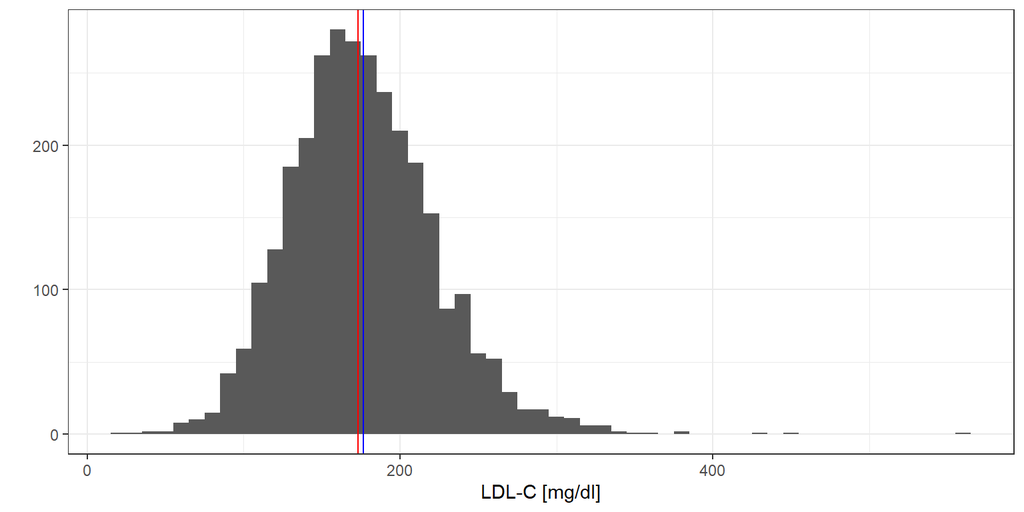

Figure 1: Distribution of LDL-C serum concentrations. The mean is depcited in blue, and the median in red.

```r
mean_ldl <- mean(framingham$LDLC, na.rm = T)
median_ldl <- median(framingham$LDLC, na.rm = T)

ggplot(framingham, aes(x = LDLC)) + geom_histogram(binwidth = 10) +
  geom_vline(xintercept = mean_ldl, colour = "blue") +
  geom_vline(xintercept = median_ldl, colour = "red") +
  xlab(label = "LDL-C [mg/dl]") + ylab(label = "") + theme_bw()
```

## Testing for normality

To compare whether there is a difference in LDL-C concentrations in dead and alive people, we first look at the distribution of LDL-C concentrations in both groups. We do this to look whether both groups are distributed normally. We see in following figure a light skew to the right.

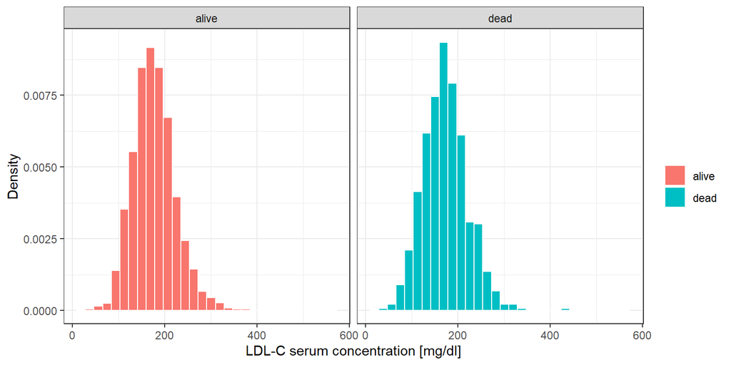

Figure 2: Distribution of LDL-C serum concentrations for dead and alive people.

```r
framingham <- framingham %>% mutate(DEATH = factor(DEATH, levels = c(0,1), labels = c("alive", "dead" )))

ggplot(framingham, aes(x = LDLC, fill = DEATH)) + geom_histogram(aes(y = after_stat(density)), colour = "white") + scale_fill_discrete(name = "", labels = c("alive", "dead")) +
  xlab("LDL-C serum concentration [mg/dl]") + ylab("Density") + facet_wrap(~DEATH) + theme_bw()
```

To furthe investigate, I display the QQ-plot for both groups.

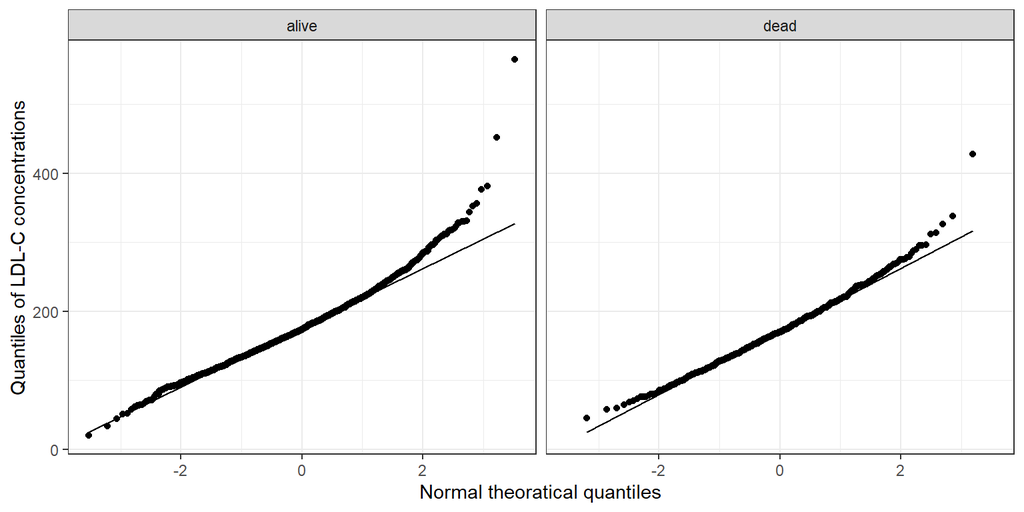

Figure 3: QQ-Plot of LDL-C serum concentrations for both dead and alive.

```r
ggplot(framingham, aes(sample = LDLC)) + geom_qq() + geom_qq_line() + facet_wrap(~DEATH) + xlab("Normal theoratical quantiles") + ylab("Quantiles of LDL-C concentrations") + theme_bw()
```

As an analytical measure for normality, I computed the kolmogorov-smirnov statistic. For alive patients:

```r
ks.test(framingham$LDLC[framingham$DEATH == "alive"], "pnorm")
```

```
    Asymptotic one-sample Kolmogorov-Smirnov test

data:  framingham$LDLC[framingham$DEATH == "alive"]
D = 1, p-value < 2.2e-16
alternative hypothesis: two-sided
```

As the p-value is very small, the evidence for non-nomality is strong.

For dead patients:

```r
ks.test(framingham$LDLC[framingham$DEATH == "dead"], "pnorm")
```

```
    Asymptotic one-sample Kolmogorov-Smirnov test

data:  framingham$LDLC[framingham$DEATH == "dead"]
D = 1, p-value < 2.2e-16
alternative hypothesis: two-sided
```

Also for this group, the evidence is strong that the data follow non-normal distribution.

## Comparison of distributions

I computed some descriptive statistics for LDL-C concentrations for both dead and alive people.

```r
framingham %>% group_by(DEATH) %>% summarise(mean = mean(LDLC, na.rm = T), SD = sd(LDLC, na.rm =T), median = median(LDLC, na.rm =T), min = min(LDLC, na.rm = T), max = max(LDLC, na.rm = T))
```

| DEATH | mean | SD | median | min | max |
| --- | --- | --- | --- | --- | --- |
| alive | 177.6121 | 46.66314 | 174 | 20 | 565 |
| dead | 172.7040 | 47.35403 | 170 | 45 | 428 |

A further comparison of LDL-C concentrations in dead and alive patients, we show in following boxplot.

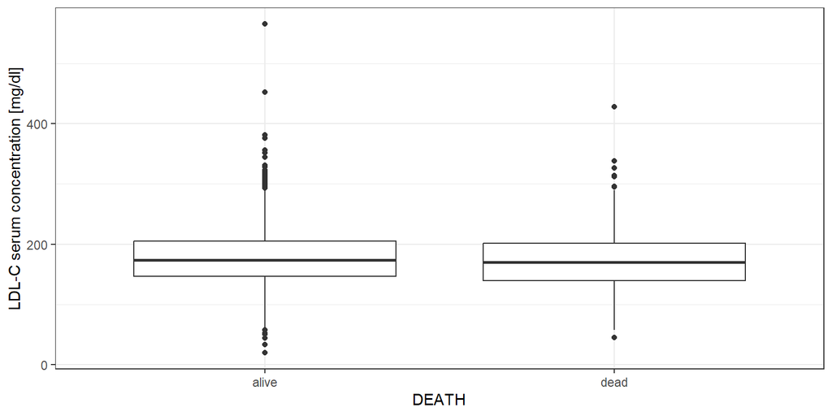

Figure 4: Boxplot of the distributions of LDL-C serum concentrations in dead and alive patients.

```r
ggplot(framingham, aes(x = DEATH, y = LDLC)) + geom_boxplot() +
  ylab("LDL-C serum concentration [mg/dl]") +
  theme_bw()
```

To describe whether the medians differ significantly, we compute the wilcoxon test.

```r
framingham %>% wilcox_test(LDLC~DEATH) %>% kable()
```

| .y. | group1 | group2 | n1 | n2 | statistic | p |
| --- | --- | --- | --- | --- | --- | --- |
| LDLC | alive | dead | 2320 | 706 | 864549.5 | 0.0249 |

There is moderate evidence that the difference in medians is significant according to the wilcoxon test. As per the clinical relevance, I argue that such a small difference likely has little impact.